[figure not shown]

# Makroökonomik II: Zusätzliches Material

Winter Semester 2021/2022

by Markus Mößler

# Konjunktur Aktuell

*Dieses Dokument enthält Veröffentlichungen ausgewählter Stimmungs- und Aktivitätsindikatoren.*

## Einordnung

Für die Einordnung siehe Kapitel 2 “Wohlstand Beschreiben.”

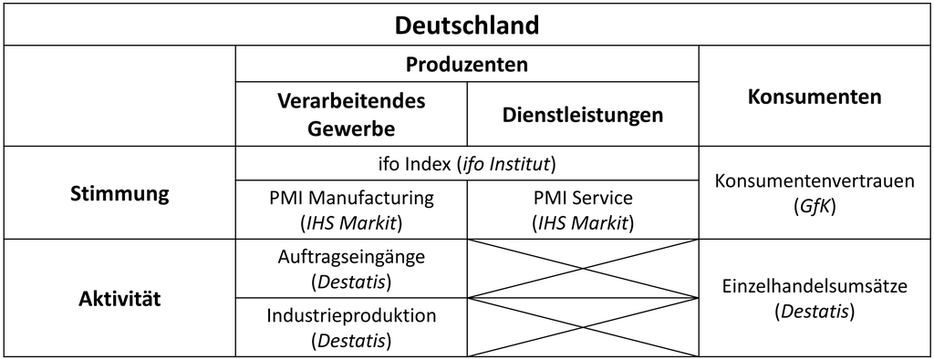

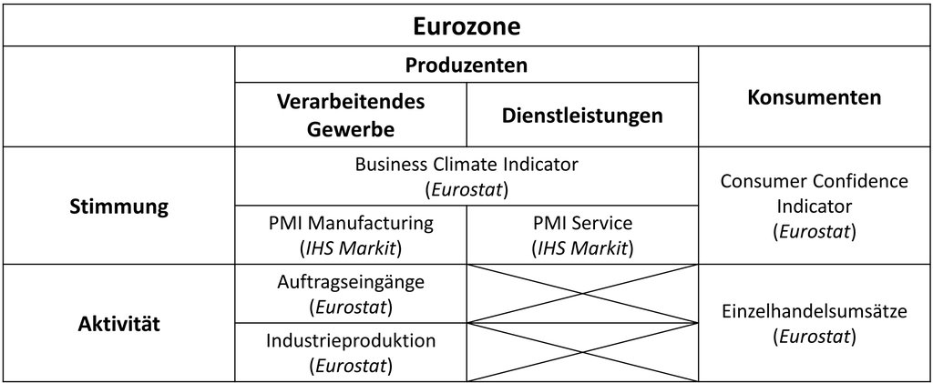

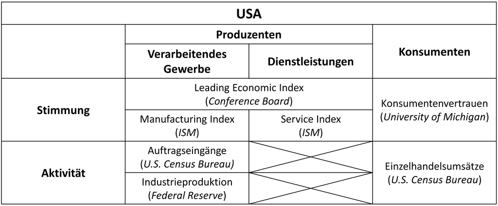

## Simmungsindikatoren

### Ifo Geschäftsklima Index

Überblick

- Einordnung: Produzenten (generell)
- Region: Deutschland
- Herausgeber: Ifo-Institut
- Link: [siehe](https://www.ifo.de/umfrage/ifo-geschaeftsklimaindex)

Weitere Informationen

Der Ifo Geschäftsklima Index ist eine der wichtigsten Messzahlen der die Stiummung in der “realen” Wirtschaft darzustellen.

Dem gegenüber steht der ZEW-Index für die Abbildung der Stimmmung auf den Finanzmärkten.

Ergebnisse

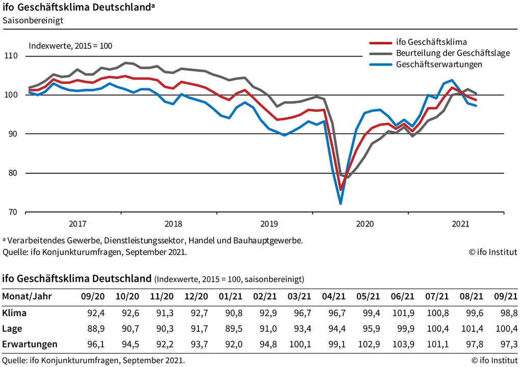

Quelle: Ifo Insitut, 24. September 2021

[figure not shown]

Quelle: Ifo Insitut, 24. September 2021

[figure not shown]

Quelle: Ifo Insitut, 24. September 2021

### ISM Index

Überblick

- Einordnung: Produzenten (generell)
- Region: USA
- Herausgeber: Institute for Supply Management (ISM)
- Link: [siehe](https://www.ismworld.org/supply-management-news-and-reports/reports/ism-report-on-business/)

Weitere Informationen

Der ISM Index ist eine der wichtigsten Messzahlen der die Stimmung in der “realen” Wirtschaft, d.h. im Dienstleistungssektor und im verarbeitendne Gewerbe darstellt.

Ergebnisse

[figure not shown]

[figure not shown]

### University of Michigan Konsumentenvertrauen

Überblick

- Einordnung: Konsumenten
- Region: USA
- Herausgeber: University of Michigan
- Link: [siehe](http://www.sca.isr.umich.edu/)

Weitere Informationen

Das University of Michigan Konsumentenvertrauen ist eine der wichtigsten Messzahlen der die Stimmung der Konsumenten in den USA und damit eine der wichtisgen Stimmungsindikatoren für die Nachfrageseite generell.

Ergebnisse

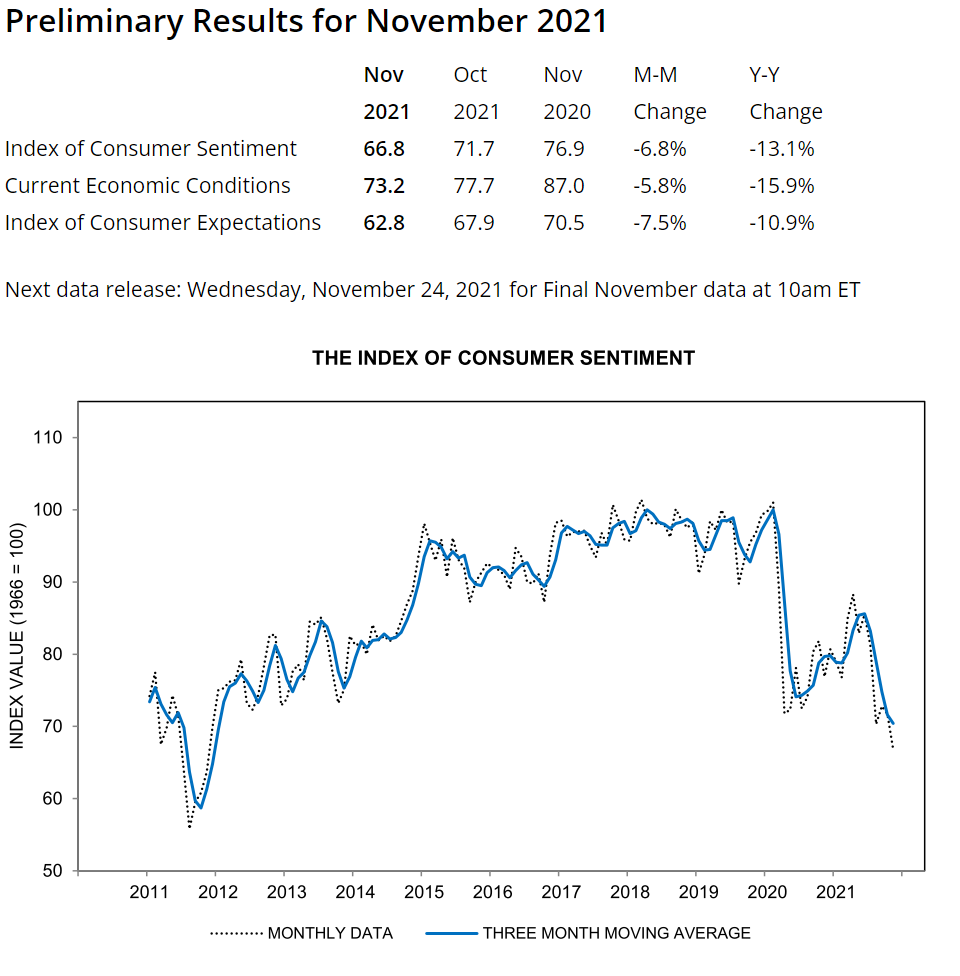

Quelle: University of Michigan, 12. November 2021

## Preise

### Inflationsrate

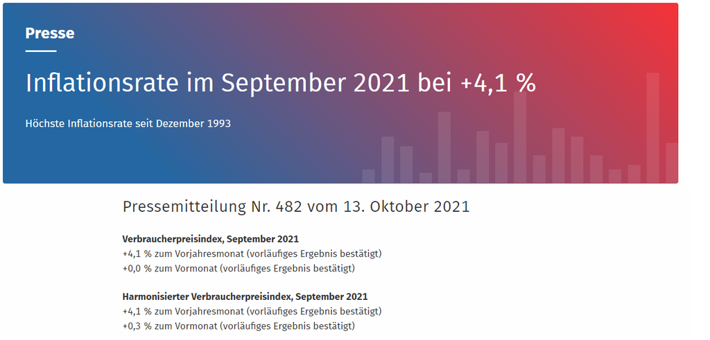

[figure not shown]

Link: [Siehe Destatis](https://www.destatis.de/DE/Presse/Pressemitteilungen/2021/10/PD21_482_611.html)

Quelle: Destatis, 13. Oktober 2021

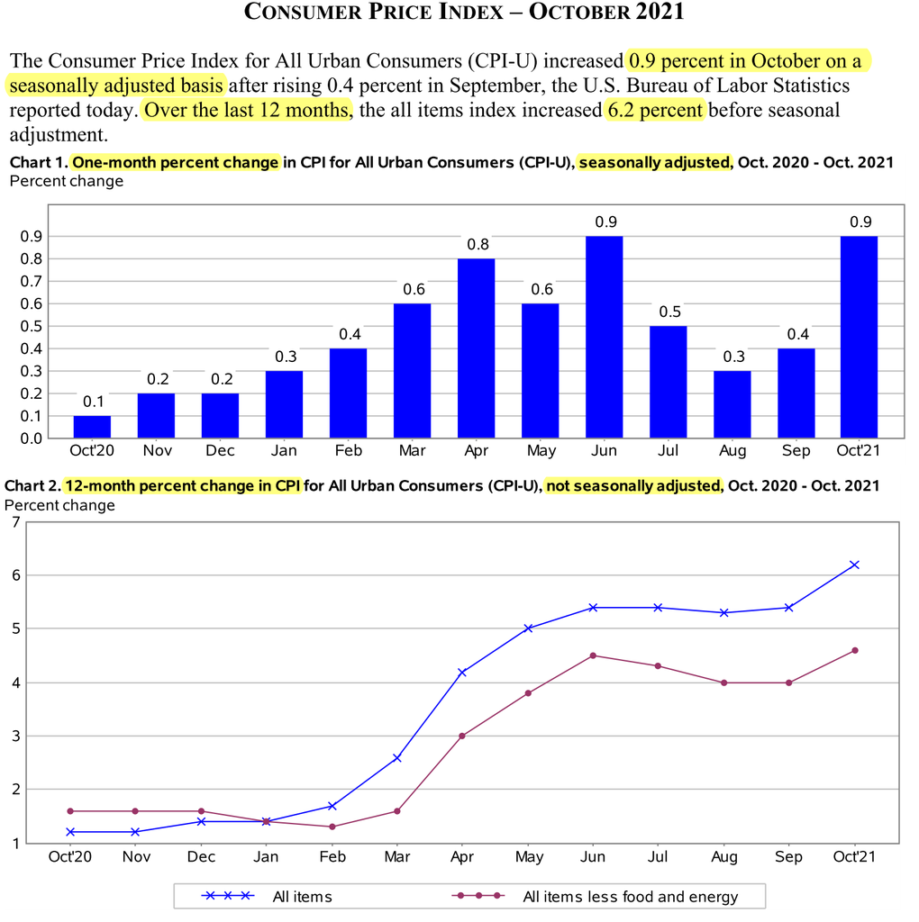

Link: [Siehe BLS](https://www.bls.gov/bls/newsrels.htm#latest-releases)

Quelle: BLS, 10. November 2021

## Wohlstand

### Bruttoinlandsprodukt

Link: [Siehe: Destatis](https://www.destatis.de/DE/Presse/Pressemitteilungen/2021/10/PD21_501_811.html)

Link: [Siehe: Bureau of Economic Analysis (BEA)](https://www.bea.gov/news/2021/gross-domestic-product-3rd-quarter-2021-advance-estimate)